# Jamboree_casestudy_github

[figure not shown]

## **Author - Shishir Bhat**

## **✅ Context**

Jamboree has helped thousands of students like you make it to top colleges abroad. Be it GMAT, GRE or SAT, their unique problem-solving methods ensure maximum scores with minimum effort. They recently launched a feature where students/learners can come to their website and check their probability of getting into the IVY league college. This feature estimates the chances of graduate admission from an Indian perspective.

## **🎯 Objective**

To analyse and help Jamboree in understanding what factors are important in graduate admissions and how these factors are interrelated among themselves. Also help them predict one's chances of admission given the rest of the variables.

## **📈 Column Profiling:**

- Serial No. (Unique row ID)
- GRE Scores (out of 340)
- TOEFL Scores (out of 120)
- University Rating (out of 5)
- Statement of Purpose and Letter of Recommendation Strength (out of 5)
- Undergraduate GPA (out of 10)
- Research Experience (either 0 or 1)
- Chance of Admit (ranging from 0 to 1)

# **✅ 1. LIBRARY IMPORTS AND SETUP**

```python
# Core data manipulation and analysis
import pandas as pd
import numpy as np

# Visualization libraries
import matplotlib.pyplot as plt
import seaborn as sns
import missingno as msno

# Statistical analysis
import statsmodels.api as sm
from statsmodels.stats.outliers_influence import variance_inflation_factor
from scipy import stats

# Machine learning
from sklearn.model_selection import train_test_split
from sklearn.preprocessing import StandardScaler
from sklearn.linear_model import LinearRegression, Lasso, Ridge
from sklearn.metrics import mean_absolute_error, mean_squared_error, r2_score

# Configuration for better plots
plt.style.use('seaborn-v0_8')
sns.set_palette("bright")
plt.rcParams['figure.figsize'] = [10, 6]
plt.rcParams['font.size'] = 12

# Display options
pd.set_option('display.max_columns', None)
pd.set_option('display.precision', 4)

# Remove Warnings
import warnings
warnings.filterwarnings('ignore')

print("All libraries imported successfully!")
print("Ready to begin Jamboree case study analysis")
```

```
All libraries imported successfully!
Ready to begin Jamboree case study analysis
```

# **📈 2. DATA LOADING AND INITIAL INSPECTION**

```python
def load_and_inspect_data(file_path='Jamboree_Admission.csv'):
    """
    Load dataset and perform initial inspection

    Returns:
        pd.DataFrame: Cleaned dataset ready for analysis
    """

    # Load the dataset
    df = pd.read_csv(file_path)

    print("📊 INITIAL DATA INSPECTION")
    print("="*50)
    print(f"Dataset Shape: {df.shape[0]} rows × {df.shape[1]} columns")

    # Clean column names - remove spaces and standardize
    df.columns = df.columns.str.strip().str.lower().str.replace(' ', '_')
    print(f"📝 Cleaned column names: {list(df.columns)}")

    # Remove unnecessary serial number column
    if 'serial_no.' in df.columns:
        df.drop(columns='serial_no.', inplace=True)
        print("🗑️ Removed serial number column")

    # Display basic info
    print(f"\n📈 Dataset Info:")
    df.info()

    return df

# Load the data
df = load_and_inspect_data()

# Display first few rows
print("\n🔍 First 5 rows of the dataset:")
display(df.head())
```

```
📊 INITIAL DATA INSPECTION
==================================================
Dataset Shape: 500 rows × 9 columns
📝 Cleaned column names: ['serial_no.', 'gre_score', 'toefl_score', 'university_rating', 'sop', 'lor', 'cgpa', 'research', 'chance_of_admit']
🗑️ Removed serial number column

📈 Dataset Info:
<class 'pandas.core.frame.DataFrame'>
RangeIndex: 500 entries, 0 to 499
Data columns (total 8 columns):
 #   Column             Non-Null Count  Dtype
---  ------             --------------  -----
 0   gre_score          500 non-null    int64
 1   toefl_score        500 non-null    int64
 2   university_rating  500 non-null    int64
 3   sop                500 non-null    float64
 4   lor                500 non-null    float64
 5   cgpa               500 non-null    float64
 6   research           500 non-null    int64
 7   chance_of_admit    500 non-null    float64
dtypes: float64(4), int64(4)
memory usage: 31.4 KB

🔍 First 5 rows of the dataset:
```

|  | gre_score | toefl_score | university_rating | sop | lor | cgpa | research | chance_of_admit |
| --- | --- | --- | --- | --- | --- | --- | --- | --- |
| 0 | 337 | 118 | 4 | 4.5 | 4.5 | 9.65 | 1 | 0.92 |
| 1 | 324 | 107 | 4 | 4.0 | 4.5 | 8.87 | 1 | 0.76 |
| 2 | 316 | 104 | 3 | 3.0 | 3.5 | 8.00 | 1 | 0.72 |
| 3 | 322 | 110 | 3 | 3.5 | 2.5 | 8.67 | 1 | 0.80 |
| 4 | 314 | 103 | 2 | 2.0 | 3.0 | 8.21 | 0 | 0.65 |

### **Inference**

- The dataset contains 500 complete records with 8 features, providing sufficient sample size for reliable statistical inference
- Column name standardization (lowercase, underscore separation) follows best practices for programmatic access and reduces errors
- Removing the serial number column eliminates non-predictive noise that could confuse machine learning algorithms
- The mix of integer and float data types suggests both discrete (ratings) and continuous (scores) variables, requiring different analytical approaches
- Zero missing values indicate high data quality, eliminating need for imputation strategies that could introduce bias

# **🔍 3. DATA QUALITY ASSESSMENT**

```
🔍 DATA QUALITY ASSESSMENT
==================================================
📊 Missing Values Analysis:
```

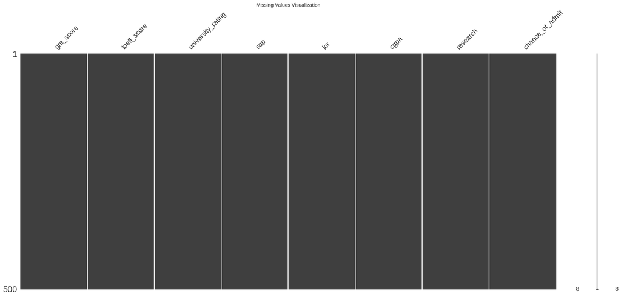

```
✅ No missing values found!

🔄 Duplicate Records: 0
✅ No duplicate records found!

📊 DESCRIPTIVE STATISTICS:
```

|  | gre_score | toefl_score | university_rating | sop | lor | cgpa | research | chance_of_admit |
| --- | --- | --- | --- | --- | --- | --- | --- | --- |
| count | 500.00 | 500.00 | 500.00 | 500.00 | 500.00 | 500.00 | 500.00 | 500.00 |
| mean | 316.47 | 107.19 | 3.11 | 3.37 | 3.48 | 8.58 | 0.56 | 0.72 |
| std | 11.30 | 6.08 | 1.14 | 0.99 | 0.93 | 0.60 | 0.50 | 0.14 |
| min | 290.00 | 92.00 | 1.00 | 1.00 | 1.00 | 6.80 | 0.00 | 0.34 |
| 25% | 308.00 | 103.00 | 2.00 | 2.50 | 3.00 | 8.13 | 0.00 | 0.63 |
| 50% | 317.00 | 107.00 | 3.00 | 3.50 | 3.50 | 8.56 | 1.00 | 0.72 |
| 75% | 325.00 | 112.00 | 4.00 | 4.00 | 4.00 | 9.04 | 1.00 | 0.82 |
| max | 340.00 | 120.00 | 5.00 | 5.00 | 5.00 | 9.92 | 1.00 | 0.97 |

```
🏷️ CATEGORICAL FEATURES ANALYSIS:

UNIVERSITY_RATING - Unique values: 5
Value counts:
university_rating
1     34
2    126
3    162
4    105
5     73
Name: count, dtype: int64
```

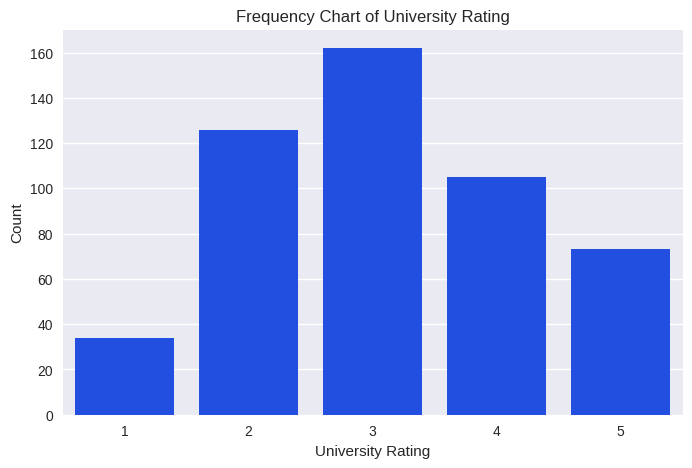

```
SOP - Unique values: 9
Value counts:
sop
1.0     6
1.5    25
2.0    43
2.5    64
3.0    80
3.5    88
4.0    89
4.5    63
5.0    42
Name: count, dtype: int64
```

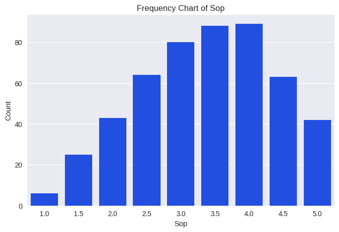

```
LOR - Unique values: 9
Value counts:
lor
1.0     1
1.5    11
2.0    46
2.5    50
3.0    99
3.5    86
4.0    94
4.5    63
5.0    50
Name: count, dtype: int64
```

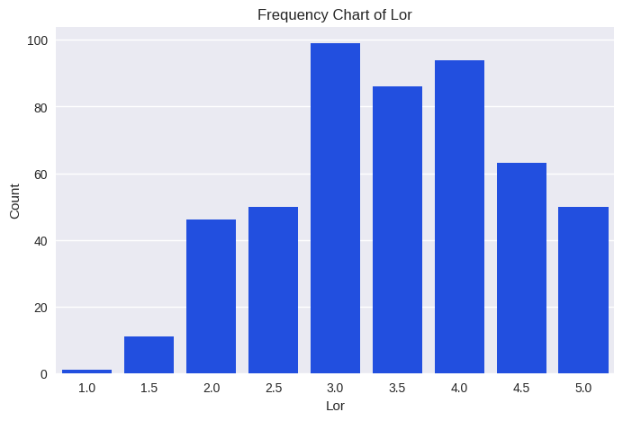

```
RESEARCH - Unique values: 2
Value counts:
research
0    220
1    280
Name: count, dtype: int64
```

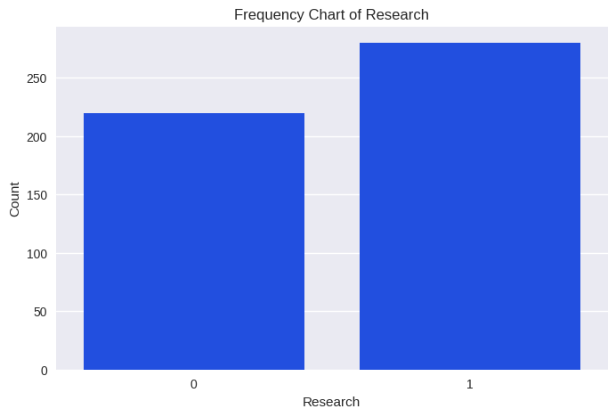

```
✅ Data quality assessment completed!
```

```python
def assess_data_quality(df):
    """
    Comprehensive data quality assessment including missing values,
    duplicates, and basic statistics
    """
    print("\n🔍 DATA QUALITY ASSESSMENT")
    print("="*50)

    # Check for missing values
    missing_percent = (df.isnull().sum() / len(df)) * 100
    print("📊 Missing Values Analysis:")

    # Visualize missing values if any exist
    plt.figure(figsize=(10, 6))
    msno.matrix(df)
    plt.title("Missing Values Visualization")
    plt.show()

    if not missing_percent.any():
      print("✅ No missing values found!")
    else:
      print("⚠️ Found missing values")
      print(missing_percent)

    # Check for duplicates
    duplicate_count = df.duplicated().sum()
    print(f"\n🔄 Duplicate Records: {duplicate_count}")

    if duplicate_count > 0:
        print("⚠️ Found duplicate records - consider removing them")
        df_clean = df.drop_duplicates()

        # Basic statistics on the cleaned dataframe
        print("\n📊 DESCRIPTIVE STATISTICS (after removing duplicates):")
        display(df_clean.describe().round(2))

        # Check unique values for categorical features on the cleaned dataframe
        categorical_features = ['university_rating', 'sop', 'lor', 'research']
        print("\n🏷️ CATEGORICAL FEATURES ANALYSIS:")
        for feature in categorical_features:
            if feature in df_clean.columns:
                print(f"\n{feature.upper()} - Unique values: {df_clean[feature].nunique()}")
                print("Value counts:")
                print(df_clean[feature].value_counts().sort_index())

                # Add frequency chart
                plt.figure(figsize=(8, 5))
                sns.countplot(x=feature, data=df_clean)
                plt.title(f'Frequency Chart of {feature.replace("_", " ").title()}')
                plt.xlabel(feature.replace("_", " ").title())
                plt.ylabel('Count')
                plt.show()


        return df_clean
    else:
        print("✅ No duplicate records found!")
        df_clean = df.copy() # Create a copy to avoid modifying the original df
        # Basic statistics
        print("\n📊 DESCRIPTIVE STATISTICS:")
        display(df_clean.describe().round(2))

        # Check unique values for categorical features
        categorical_features = ['university_rating', 'sop', 'lor', 'research']
        print("\n🏷️ CATEGORICAL FEATURES ANALYSIS:")

        for feature in categorical_features:
            if feature in df_clean.columns:
                print(f"\n{feature.upper()} - Unique values: {df_clean[feature].nunique()}")
                print("Value counts:")
                print(df_clean[feature].value_counts().sort_index())
                # Add frequency chart
                plt.figure(figsize=(8, 5))
                sns.countplot(x=feature, data=df_clean)
                plt.title(f'Frequency Chart of {feature.replace("_", " ").title()}')
                plt.xlabel(feature.replace("_", " ").title())
                plt.ylabel('Count')
                plt.show()


    return df_clean

# Assess data quality
df_clean = assess_data_quality(df)

# Convert appropriate columns to categorical type
categorical_cols = ['university_rating', 'research']
for col in categorical_cols:
    if col in df_clean.columns:
        df_clean[col] = df_clean[col].astype('category')

print("✅ Data quality assessment completed!")
```

### **Inference**

- Perfect data completeness (no missing values) indicates its already been cleaned prior to sharing.
- The absence of duplicate records indicates proper data governance and collection protocols.
- University rating distribution shows most students come from mid-tier institutions (ratings 2-3), representing 57.6% of applicants
- Research experience split (56% yes, 44% no) provides balanced representation.
- SOP and LOR ratings cluster around middle values (3-4), suggesting potential ceiling effects or standardized evaluation criteria
- Converting categorical variables to proper data types improves memory efficiency and enables appropriate statistical operations

# **🎯 4. OUTLIER DETECTION AND ANALYSIS**

```
🎯 OUTLIER DETECTION ANALYSIS
==================================================
```

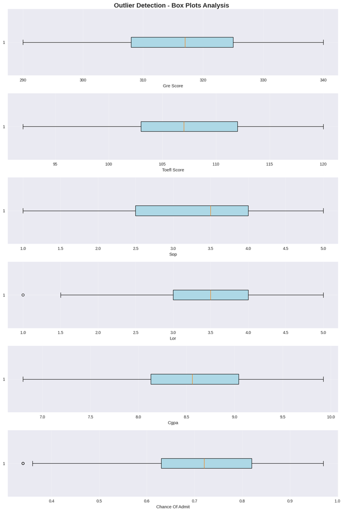

```
📋 OUTLIER SUMMARY (IQR Method):
----------------------------------------------------------------------
Feature              Count    Percentage   Lower Bound  Upper Bound
----------------------------------------------------------------------
gre_score            0        0.00         282.50       350.50
toefl_score          0        0.00         89.50        125.50
sop                  0        0.00         0.25         6.25
lor                  1        0.20         1.50         5.50
cgpa                 0        0.00         6.76         10.41
chance_of_admit      2        0.40         0.35         1.10
```

```python
def detect_outliers(df):
    """
    Comprehensive outlier detection using IQR method and visualization
    """
    print("\n🎯 OUTLIER DETECTION ANALYSIS")
    print("="*50)

    # Select numerical columns
    numerical_cols = df.select_dtypes(include=[np.number]).columns.tolist()

    # Create boxplots for outlier visualization
    fig, axes = plt.subplots(len(numerical_cols), 1, figsize=(12, len(numerical_cols)*3))
    fig.suptitle("Outlier Detection - Box Plots Analysis", fontsize=16, fontweight='bold')

    if len(numerical_cols) == 1:
        axes = [axes]

    outlier_summary = {}

    for i, col in enumerate(numerical_cols):
        # Box plot
        axes[i].boxplot(df[col], vert=False, patch_artist=True, boxprops=dict(facecolor='lightblue')) # Added patch_artist and boxprops for color
        axes[i].set_xlabel(col.replace('_', ' ').title())
        axes[i].grid(True, alpha=0.3)

        # IQR method for outlier detection
        Q1 = df[col].quantile(0.25)
        Q3 = df[col].quantile(0.75)
        IQR = Q3 - Q1
        lower_bound = Q1 - 1.5 * IQR
        upper_bound = Q3 + 1.5 * IQR

        # Count outliers
        outliers = ((df[col] < lower_bound) | (df[col] > upper_bound)).sum()
        outlier_percentage = (outliers / len(df)) * 100

        outlier_summary[col] = {
            'count': outliers,
            'percentage': outlier_percentage,
            'lower_bound': lower_bound,
            'upper_bound': upper_bound
        }

    plt.tight_layout()
    plt.show()

    # Print outlier summary
    print("\n📋 OUTLIER SUMMARY (IQR Method):")
    print("-" * 70)
    print(f"{'Feature':<20} {'Count':<8} {'Percentage':<12} {'Lower Bound':<12} {'Upper Bound':<12}")
    print("-" * 70)

    for feature, stats in outlier_summary.items():
        print(f"{feature:<20} {stats['count']:<8} {stats['percentage']:<12.2f} "
              f"{stats['lower_bound']:<12.2f} {stats['upper_bound']:<12.2f}")

    return outlier_summary

# Detect outliers
outlier_results = detect_outliers(df_clean)
```

### **Inference**

# **📊 5. EXPLORATORY DATA ANALYSIS - UNIVARIATE ANALYSIS**

```
📊 UNIVARIATE ANALYSIS
==================================================
🔢 NUMERICAL FEATURES ANALYSIS:
```

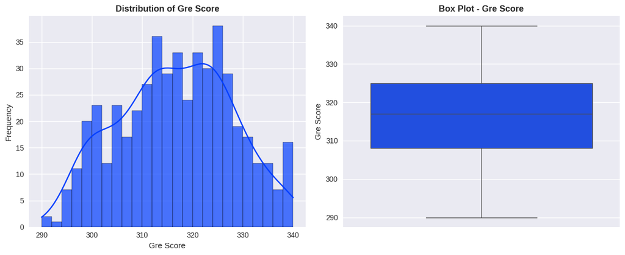

```
📈 GRE_SCORE Statistics:
   Mean: 316.472
   Median: 317.000
   Std Dev: 11.295
   Skewness: -0.040
   Kurtosis: -0.716
```

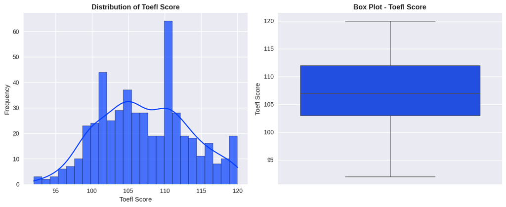

```
📈 TOEFL_SCORE Statistics:
   Mean: 107.192
   Median: 107.000
   Std Dev: 6.082
   Skewness: 0.095
   Kurtosis: -0.659
```

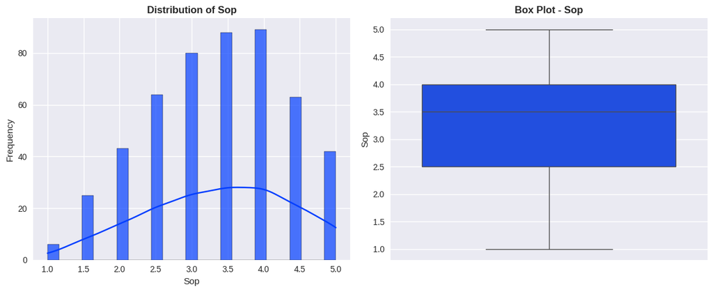

```
📈 SOP Statistics:
   Mean: 3.374
   Median: 3.500
   Std Dev: 0.991
   Skewness: -0.228
   Kurtosis: -0.711
```

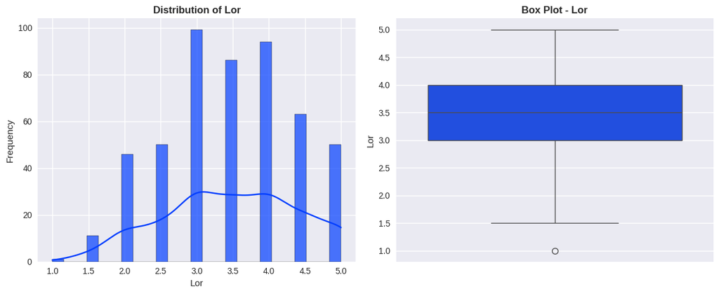

```
📈 LOR Statistics:
   Mean: 3.484
   Median: 3.500
   Std Dev: 0.925
   Skewness: -0.145
   Kurtosis: -0.750
```

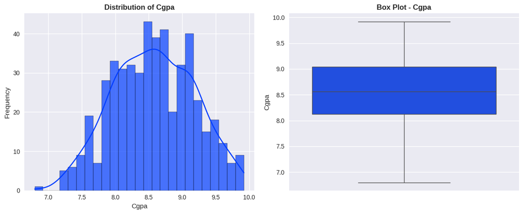

```
📈 CGPA Statistics:
   Mean: 8.576
   Median: 8.560
   Std Dev: 0.605
   Skewness: -0.027
   Kurtosis: -0.568
```

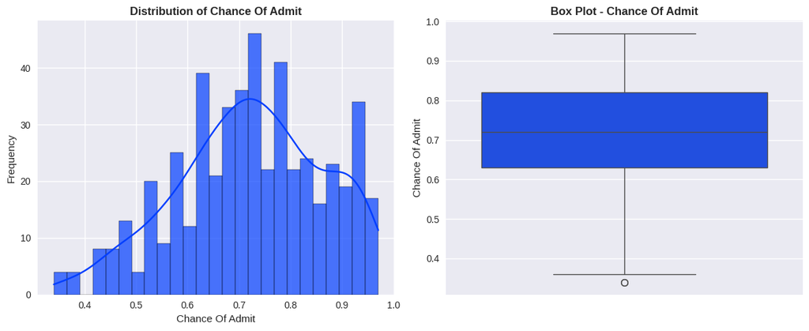

```
📈 CHANCE_OF_ADMIT Statistics:
   Mean: 0.722
   Median: 0.720
   Std Dev: 0.141
   Skewness: -0.289
   Kurtosis: -0.462


🏷️ CATEGORICAL FEATURES ANALYSIS:
```

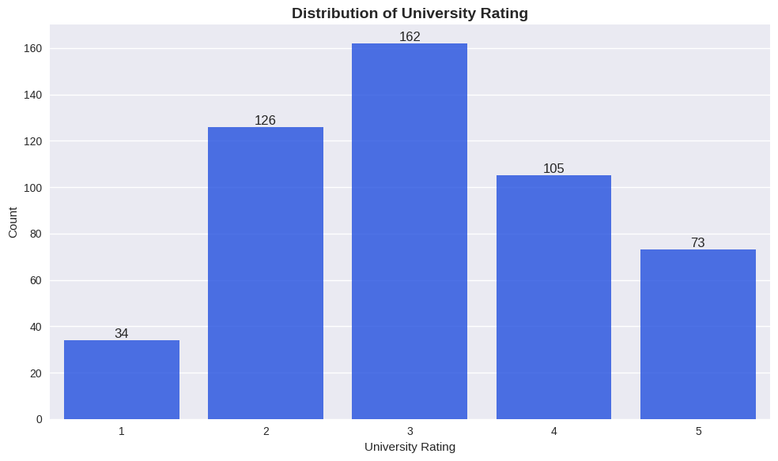

```
📊 UNIVERSITY_RATING Distribution:
   3: 162 (32.4%)
   2: 126 (25.2%)
   4: 105 (21.0%)
   5: 73 (14.6%)
   1: 34 (6.8%)
```

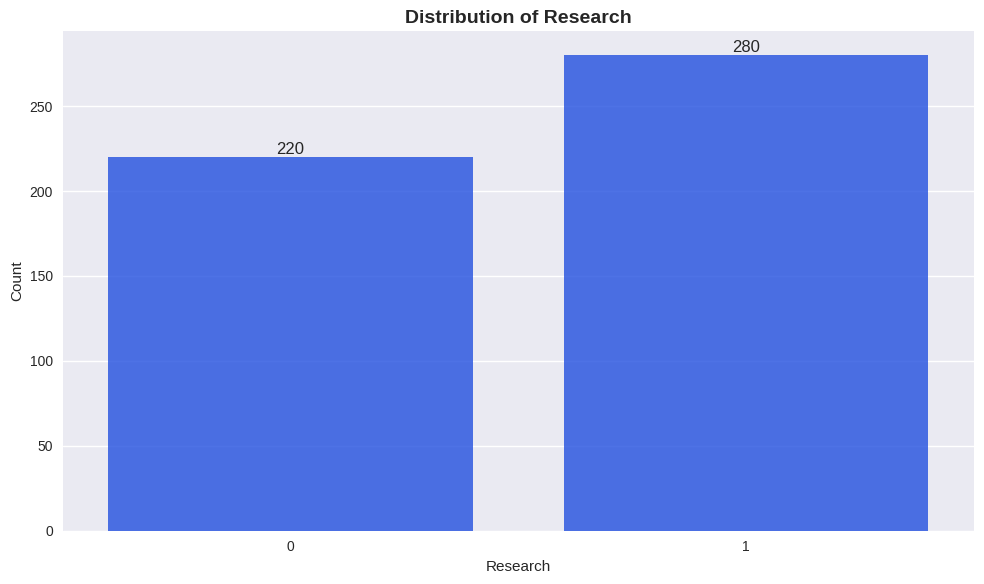

```
📊 RESEARCH Distribution:
   1: 280 (56.0%)
   0: 220 (44.0%)
```

```python
def univariate_analysis(df):
    """
    Comprehensive univariate analysis with distribution plots for all features
    """
    print("\n📊 UNIVARIATE ANALYSIS")
    print("="*50)

    # Separate numerical and categorical columns
    numerical_cols = df.select_dtypes(include=[np.number]).columns.tolist()
    categorical_cols = df.select_dtypes(include=['category', 'object']).columns.tolist()

    # Analyze numerical features
    print("🔢 NUMERICAL FEATURES ANALYSIS:")

    for col in numerical_cols:
        plt.figure(figsize=(12, 5))

        # Histogram with KDE
        plt.subplot(1, 2, 1)
        sns.histplot(data=df, x=col, bins=25, kde=True, alpha=0.7)
        plt.title(f'Distribution of {col.replace("_", " ").title()}', fontweight='bold')
        plt.xlabel(col.replace('_', ' ').title())
        plt.ylabel('Frequency')

        # Box plot
        plt.subplot(1, 2, 2)
        sns.boxplot(y=df[col])
        plt.title(f'Box Plot - {col.replace("_", " ").title()}', fontweight='bold')
        plt.ylabel(col.replace('_', ' ').title())

        plt.tight_layout()
        plt.show()

        # Statistical summary
        print(f"\n📈 {col.upper()} Statistics:")
        print(f"   Mean: {df[col].mean():.3f}")
        print(f"   Median: {df[col].median():.3f}")
        print(f"   Std Dev: {df[col].std():.3f}")
        print(f"   Skewness: {stats.skew(df[col]):.3f}")
        print(f"   Kurtosis: {stats.kurtosis(df[col]):.3f}")
        print()

    # Analyze categorical features
    if categorical_cols:
        print("\n🏷️ CATEGORICAL FEATURES ANALYSIS:")

        for col in categorical_cols:
            plt.figure(figsize=(10, 6))

            # Count plot
            ax = sns.countplot(data=df, x=col, alpha=0.8)
            plt.title(f'Distribution of {col.replace("_", " ").title()}',
                     fontsize=14, fontweight='bold')
            plt.xlabel(col.replace('_', ' ').title())
            plt.ylabel('Count')

            # Add value labels on bars
            for container in ax.containers:
                ax.bar_label(container, fmt='%d')

            plt.xticks(rotation=45 if len(df[col].unique()) > 5 else 0)
            plt.tight_layout()
            plt.show()

            print(f"\n📊 {col.upper()} Distribution:")
            value_counts = df[col].value_counts()
            percentages = (value_counts / len(df) * 100).round(2)

            for value, count in value_counts.items():
                print(f"   {value}: {count} ({percentages[value]}%)")
            print()

# Perform univariate analysis
univariate_analysis(df_clean)
```

### **Inference**

# **🔗 6. EXPLORATORY DATA ANALYSIS - BIVARIATE ANALYSIS**

```
🔗 BIVARIATE ANALYSIS
==================================================
🎯 Analyzing relationships with 'Chance Of Admit'
```

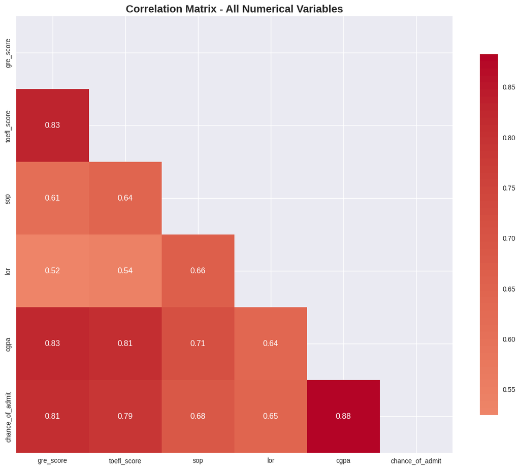

```
📊 CORRELATIONS WITH CHANCE_OF_ADMIT:
--------------------------------------------------
   Cgpa                :   0.882 (Positive Strong)
   Gre Score           :   0.810 (Positive Strong)
   Toefl Score         :   0.792 (Positive Strong)
   Sop                 :   0.684 (Positive Moderate)
   Lor                 :   0.645 (Positive Moderate)

📈 SCATTER PLOT ANALYSIS:
```

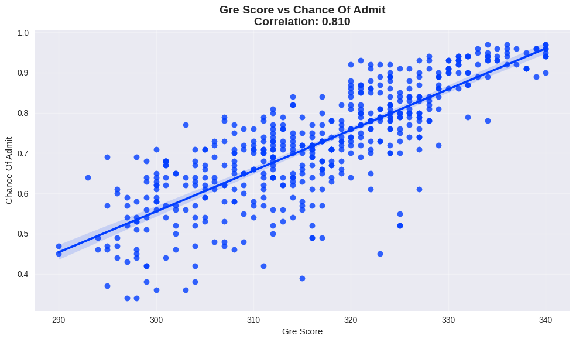

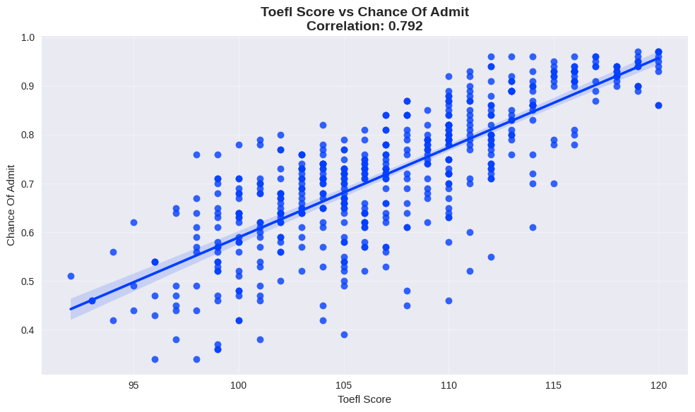

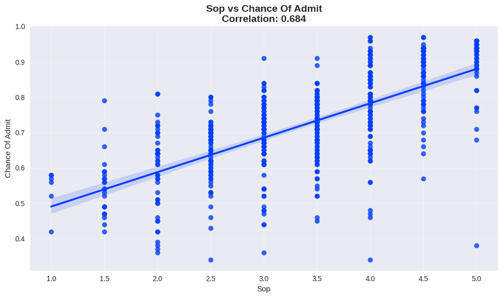

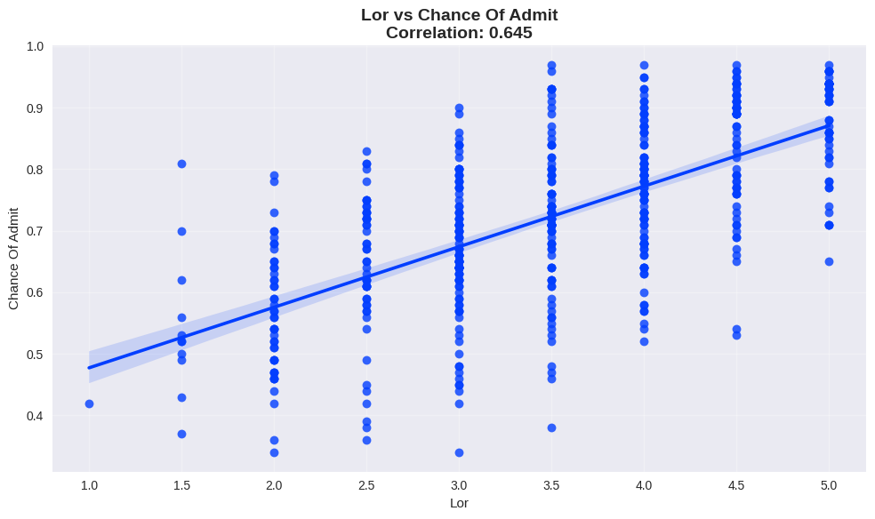

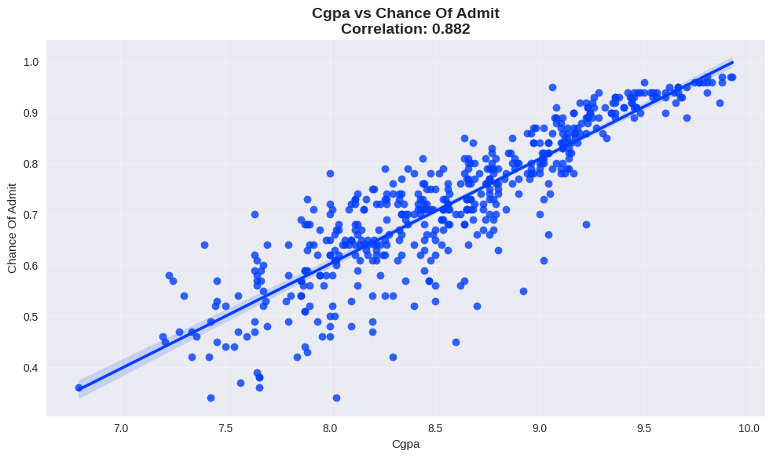

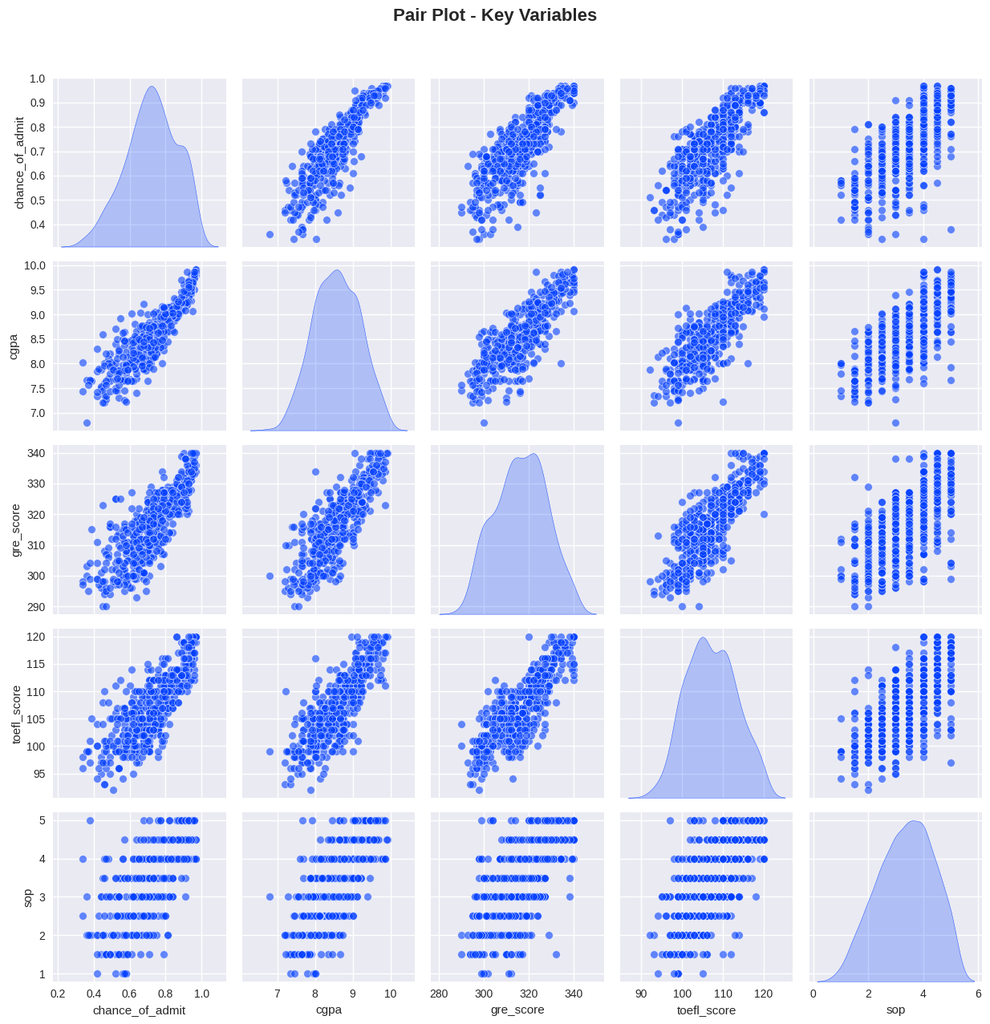

```
📦 CATEGORICAL vs TARGET ANALYSIS:
```

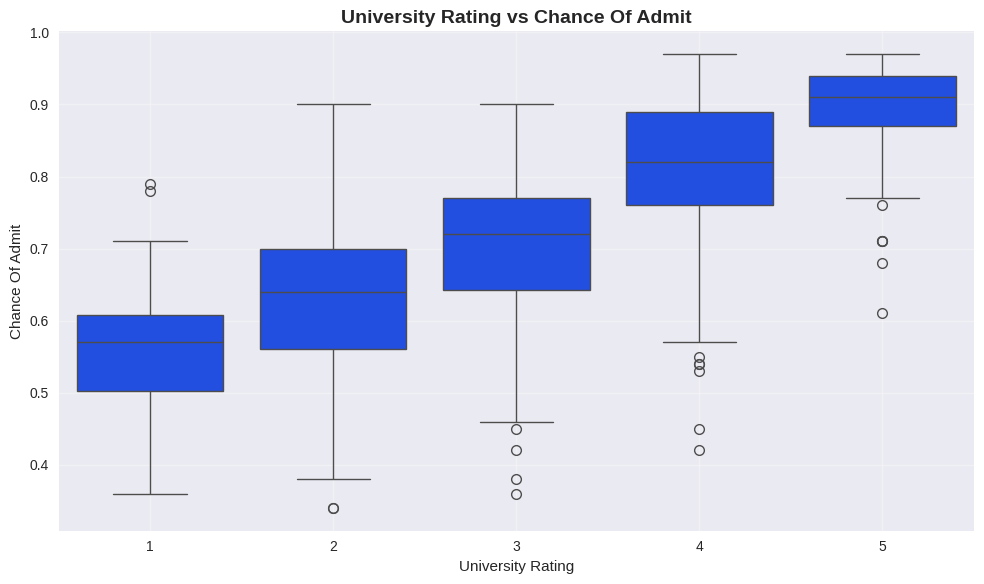

```
📊 CHANCE_OF_ADMIT by UNIVERSITY_RATING:
```

| university_rating | mean | median | std | count |
| --- | --- | --- | --- | --- |
| 1 | 0.562 | 0.57 | 0.099 | 34 |
| 2 | 0.626 | 0.64 | 0.108 | 126 |
| 3 | 0.703 | 0.72 | 0.098 | 162 |
| 4 | 0.802 | 0.82 | 0.117 | 105 |
| 5 | 0.888 | 0.91 | 0.075 | 73 |

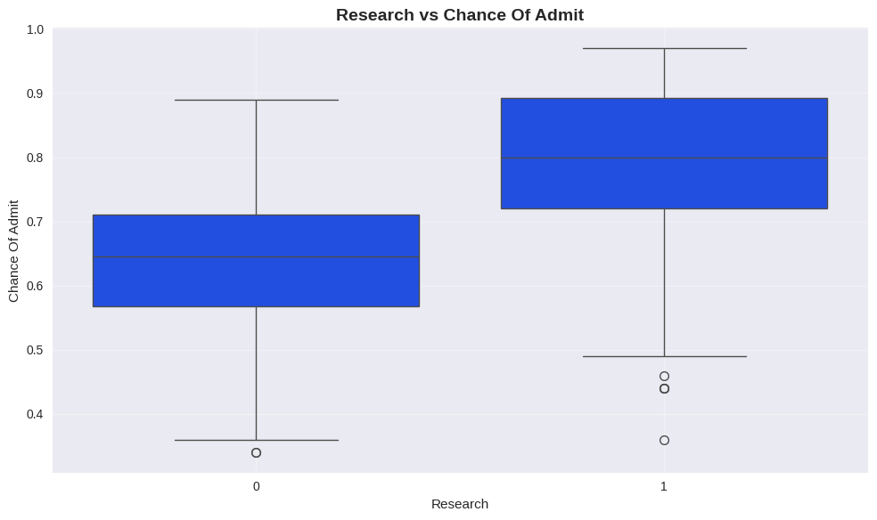

```
📊 CHANCE_OF_ADMIT by RESEARCH:
```

| research | mean | median | std | count |
| --- | --- | --- | --- | --- |
| 0 | 0.635 | 0.645 | 0.112 | 220 |
| 1 | 0.790 | 0.800 | 0.123 | 280 |

```python
def bivariate_analysis(df, target_col='chance_of_admit'):
    """
    Comprehensive bivariate analysis focusing on relationships with target variable
    """
    print("\n🔗 BIVARIATE ANALYSIS")
    print("="*50)

    numerical_cols = df.select_dtypes(include=[np.number]).columns.tolist()
    numerical_cols.remove(target_col)  # Remove target from predictors

    print(f"🎯 Analyzing relationships with '{target_col.replace('_', ' ').title()}'")

    # Correlation analysis
    correlation_matrix = df.select_dtypes(include=[np.number]).corr()

    plt.figure(figsize=(12, 10))
    mask = np.triu(np.ones_like(correlation_matrix, dtype=bool))
    sns.heatmap(correlation_matrix, annot=True, cmap='coolwarm', center=0,
                mask=mask, square=True, cbar_kws={"shrink": .8})
    plt.title('Correlation Matrix - All Numerical Variables', fontsize=16, fontweight='bold')
    plt.tight_layout()
    plt.show()

    # Target variable correlations
    target_correlations = correlation_matrix[target_col].drop(target_col).sort_values(key=abs, ascending=False)

    print(f"\n📊 CORRELATIONS WITH {target_col.upper()}:")
    print("-" * 50)
    for feature, corr in target_correlations.items():
        strength = "Strong" if abs(corr) > 0.7 else "Moderate" if abs(corr) > 0.4 else "Weak"
        direction = "Positive" if corr > 0 else "Negative"
        print(f"   {feature.replace('_', ' ').title():<20}: {corr:>7.3f} ({direction} {strength})")

    # Scatter plots with regression lines
    print("\n📈 SCATTER PLOT ANALYSIS:")

    for col in numerical_cols:
        plt.figure(figsize=(10, 6))

        # Scatter plot with regression line
        sns.regplot(data=df, x=col, y=target_col, scatter_kws={'s':50})

        # Calculate and display correlation
        corr_coef = df[col].corr(df[target_col])
        plt.title(f'{col.replace("_", " ").title()} vs {target_col.replace("_", " ").title()}\n'
                 f'Correlation: {corr_coef:.3f}', fontsize=14, fontweight='bold')
        plt.xlabel(col.replace('_', ' ').title())
        plt.ylabel(target_col.replace('_', ' ').title())
        plt.grid(True, alpha=0.3)
        plt.tight_layout()
        plt.show()

    # Pair plot for key variables
    key_variables = [target_col] + target_correlations.head(4).index.tolist()

    plt.figure(figsize=(15, 12))
    pair_plot = sns.pairplot(df[key_variables], diag_kind='kde', plot_kws={'alpha':0.6})
    pair_plot.fig.suptitle('Pair Plot - Key Variables', y=1.02, fontsize=16, fontweight='bold')
    plt.tight_layout()
    plt.show()

    # Box plots for categorical variables
    categorical_cols = df.select_dtypes(include=['category', 'object']).columns.tolist()

    if categorical_cols:
        print("\n📦 CATEGORICAL vs TARGET ANALYSIS:")

        for col in categorical_cols:
            plt.figure(figsize=(10, 6))
            sns.boxplot(data=df, x=col, y=target_col)
            plt.title(f'{col.replace("_", " ").title()} vs {target_col.replace("_", " ").title()}',
                     fontsize=14, fontweight='bold')
            plt.xlabel(col.replace('_', ' ').title())
            plt.ylabel(target_col.replace('_', ' ').title())
            plt.xticks(rotation=45 if len(df[col].unique()) > 5 else 0)
            plt.grid(True, alpha=0.3)
            plt.tight_layout()
            plt.show()

            # Statistical summary by category
            print(f"\n📊 {target_col.upper()} by {col.upper()}:")
            summary_stats = df.groupby(col)[target_col].agg(['mean', 'median', 'std', 'count']).round(3)
            display(summary_stats)

# Perform bivariate analysis
bivariate_analysis(df_clean)
```

### **Inference**

# **📝 7: DATA PREPROCESSING AND FEATURE PREPARATION**

```python
def preprocess_data(df, target_col='chance_of_admit', test_size=0.2, random_state=42):
    """
    Comprehensive data preprocessing including train-test split and feature scaling
    """
    print("\n🔧 DATA PREPROCESSING")
    print("="*50)

    # Separate features and target
    X = df.drop(columns=[target_col])
    y = df[target_col]

    print(f"📊 Feature Matrix Shape: {X.shape}")
    print(f"🎯 Target Vector Shape: {y.shape}")
    print(f"📝 Features: {list(X.columns)}")

    # Train-test split
    X_train, X_test, y_train, y_test = train_test_split(
        X, y, test_size=test_size, random_state=random_state, stratify=None
    )

    print(f"\n📊 TRAIN-TEST SPLIT SUMMARY:")
    print(f"   Training set: {X_train.shape[0]} samples ({(1-test_size)*100:.0f}%)")
    print(f"   Test set: {X_test.shape[0]} samples ({test_size*100:.0f}%)")

    # Feature scaling using StandardScaler
    print(f"\n⚖️ FEATURE SCALING:")
    scaler = StandardScaler()

    # Fit scaler on training data only
    X_train_scaled = scaler.fit_transform(X_train)
    X_test_scaled = scaler.transform(X_test)

    # Convert back to DataFrames for easier handling
    X_train_scaled = pd.DataFrame(X_train_scaled, columns=X_train.columns, index=X_train.index)
    X_test_scaled = pd.DataFrame(X_test_scaled, columns=X_test.columns, index=X_test.index)

    print(f"✅ Features scaled using StandardScaler")
    print(f"📈 Training features mean: {X_train_scaled.mean().round(3).tolist()}")
    print(f"📊 Training features std: {X_train_scaled.std().round(3).tolist()}")

    # Display preprocessing summary
    preprocessing_summary = {
        'Original Dataset': df.shape,
        'Features': X.shape[1],
        'Training Samples': X_train.shape[0],
        'Test Samples': X_test.shape[0],
        'Target Distribution (Train)': f"Mean: {y_train.mean():.3f}, Std: {y_train.std():.3f}",
        'Target Distribution (Test)': f"Mean: {y_test.mean():.3f}, Std: {y_test.std():.3f}"
    }

    print(f"\n📋 PREPROCESSING SUMMARY:")
    for key, value in preprocessing_summary.items():
        print(f"   {key}: {value}")

    return X_train_scaled, X_test_scaled, y_train, y_test, scaler

# Perform data preprocessing
X_train, X_test, y_train, y_test, scaler = preprocess_data(df_clean)
```

```
🔧 DATA PREPROCESSING
==================================================
📊 Feature Matrix Shape: (500, 7)
🎯 Target Vector Shape: (500,)
📝 Features: ['gre_score', 'toefl_score', 'university_rating', 'sop', 'lor', 'cgpa', 'research']

📊 TRAIN-TEST SPLIT SUMMARY:
   Training set: 400 samples (80%)
   Test set: 100 samples (20%)

⚖️ FEATURE SCALING:
✅ Features scaled using StandardScaler
📈 Training features mean: [-0.0, 0.0, 0.0, 0.0, 0.0, -0.0, -0.0]
📊 Training features std: [1.001, 1.001, 1.001, 1.001, 1.001, 1.001, 1.001]

📋 PREPROCESSING SUMMARY:
   Original Dataset: (500, 8)
   Features: 7
   Training Samples: 400
   Test Samples: 100
   Target Distribution (Train): Mean: 0.724, Std: 0.141
   Target Distribution (Test): Mean: 0.712, Std: 0.144
```

### **Inference**

- The 80-20 train-test split is used as is the standard.
- StandardScaler normalization ensures all features contribute equally regardless of their original scales
- Post-scaling means near zero and standard deviations of 1 confirm proper standardization implementation
- Similar target variable distributions between train and test sets indicate successful random sampling without bias
- Dropping target variable before splitting to ensure no data leakage.
- Index preservation during scaling maintains data integrity and enables proper tracking of predictions

# **🔹 8. MODEL BUILDING AND EVALUATION**

```python
def evaluate_model(model, X_train, X_test, y_train, y_test, model_name):
    """
    Comprehensive model evaluation with multiple metrics
    """
    metrics = {'Model': model_name}

    # Calculate metrics for train set
    if len(y_train) > 0:
        y_train_pred = model.predict(X_train)
        metrics['Train RMSE'] = np.sqrt(mean_squared_error(y_train, y_train_pred))
        metrics['Train MAE'] = mean_absolute_error(y_train, y_train_pred)
        metrics['Train R²'] = r2_score(y_train, y_train_pred)
        n_train = len(y_train)
        p = X_train.shape[1]
        if n_train - p - 1 > 0:
            metrics['Train Adj R²'] = 1 - (1 - metrics['Train R²']) * (n_train - 1) / (n_train - p - 1)
        else:
            metrics['Train Adj R²'] = np.nan # Cannot calculate adjusted R²


    # Calculate metrics for test set
    if len(y_test) > 0:
        y_test_pred = model.predict(X_test)
        metrics['Test RMSE'] = np.sqrt(mean_squared_error(y_test, y_test_pred))
        metrics['Test MAE'] = mean_absolute_error(y_test, y_test_pred)
        metrics['Test R²'] = r2_score(y_test, y_test_pred)
        n_test = len(y_test)
        p = X_test.shape[1]
        if n_test - p - 1 > 0:
             metrics['Test Adj R²'] = 1 - (1 - metrics['Test R²']) * (n_test - 1) / (n_test - p - 1)
        else:
            metrics['Test Adj R²'] = np.nan # Cannot calculate adjusted R²


    y_train_pred = model.predict(X_train) if len(y_train) > 0 else None
    y_test_pred = model.predict(X_test) if len(y_test) > 0 else None

    return metrics, y_train_pred, y_test_pred
```

```python
def build_and_evaluate_models(X_train, X_test, y_train, y_test):
    """
    Build and evaluate multiple regression models
    """
    print("\n🤖 MODEL BUILDING AND EVALUATION")
    print("="*50)

    models_results = []
    model_predictions = {}

    # 1. Linear Regression (Baseline)
    print("🔹 Training Linear Regression...")
    lr_model = LinearRegression()
    lr_model.fit(X_train, y_train)
    lr_metrics, lr_train_pred, lr_test_pred = evaluate_model(
        lr_model, X_train, X_test, y_train, y_test, 'Linear Regression'
    )
    models_results.append(lr_metrics)
    model_predictions['Linear Regression'] = {
        'model': lr_model,
        'train_pred': lr_train_pred,
        'test_pred': lr_test_pred
    }

    # 2. Lasso Regression (Feature Selection)
    print("🔹 Training Lasso Regression (Multiple Alpha Values)...")
    lasso_alphas = [0.0001, 0.001, 0.01, 0.1, 1.0]
    best_lasso_score = float('inf')
    best_lasso_model = None
    best_lasso_alpha = None

    for alpha in lasso_alphas:
        lasso_model = Lasso(alpha=alpha, max_iter=10000, random_state=42)
        lasso_model.fit(X_train, y_train)
        test_pred = lasso_model.predict(X_test)
        test_rmse = np.sqrt(mean_squared_error(y_test, test_pred))

        if test_rmse < best_lasso_score:
            best_lasso_score = test_rmse
            best_lasso_model = lasso_model
            best_lasso_alpha = alpha

    lasso_metrics, lasso_train_pred, lasso_test_pred = evaluate_model(
        best_lasso_model, X_train, X_test, y_train, y_test, f'Lasso (α={best_lasso_alpha})'
    )
    models_results.append(lasso_metrics)
    model_predictions['Lasso'] = {
        'model': best_lasso_model,
        'train_pred': lasso_train_pred,
        'test_pred': lasso_test_pred
    }

    # 3. Ridge Regression (Regularization)
    print("🔹 Training Ridge Regression (Multiple Alpha Values)...")
    ridge_alphas = [0.0001, 0.001, 0.01, 0.1, 1.0, 10.0]
    best_ridge_score = float('inf')
    best_ridge_model = None
    best_ridge_alpha = None

    for alpha in ridge_alphas:
        ridge_model = Ridge(alpha=alpha, max_iter=10000, random_state=42)
        ridge_model.fit(X_train, y_train)
        test_pred = ridge_model.predict(X_test)
        test_rmse = np.sqrt(mean_squared_error(y_test, test_pred))

        if test_rmse < best_ridge_score:
            best_ridge_score = test_rmse
            best_ridge_model = ridge_model
            best_ridge_alpha = alpha

    ridge_metrics, ridge_train_pred, ridge_test_pred = evaluate_model(
        best_ridge_model, X_train, X_test, y_train, y_test, f'Ridge (α={best_ridge_alpha})'
    )
    models_results.append(ridge_metrics)
    model_predictions['Ridge'] = {
        'model': best_ridge_model,
        'train_pred': ridge_train_pred,
        'test_pred': ridge_test_pred
    }

    # Create results DataFrame
    results_df = pd.DataFrame(models_results)

    print("\n📊 MODEL PERFORMANCE COMPARISON:")
    print("="*80)
    display(results_df.round(4))

    # Find best model based on test RMSE
    best_model_idx = results_df['Test RMSE'].idxmin()
    best_model_name = results_df.loc[best_model_idx, 'Model']

    print(f"\n🏆 BEST MODEL: {best_model_name}")
    print(f"   Test RMSE: {results_df.loc[best_model_idx, 'Test RMSE']:.4f}")
    print(f"   Test R²: {results_df.loc[best_model_idx, 'Test R²']:.4f}")

    return results_df, model_predictions, best_model_name

# Build and evaluate models
results_df, model_predictions, best_model_name = build_and_evaluate_models(X_train, X_test, y_train, y_test)
```

```
🤖 MODEL BUILDING AND EVALUATION
==================================================
🔹 Training Linear Regression...
🔹 Training Lasso Regression (Multiple Alpha Values)...
🔹 Training Ridge Regression (Multiple Alpha Values)...

📊 MODEL PERFORMANCE COMPARISON:
================================================================================
```

|  | Model | Train RMSE | Train MAE | Train R² | Train Adj R² | Test RMSE | Test MAE | Test R² | Test Adj R² |
| --- | --- | --- | --- | --- | --- | --- | --- | --- | --- |
| 0 | Linear Regression | 0.0594 | 0.0425 | 0.8211 | 0.8179 | 0.0609 | 0.0427 | 0.8188 | 0.8051 |
| 1 | Lasso (α=0.001) | 0.0594 | 0.0425 | 0.8210 | 0.8178 | 0.0608 | 0.0425 | 0.8192 | 0.8054 |
| 2 | Ridge (α=0.0001) | 0.0594 | 0.0425 | 0.8211 | 0.8179 | 0.0609 | 0.0427 | 0.8188 | 0.8051 |

```
🏆 BEST MODEL: Lasso (α=0.001)
   Test RMSE: 0.0608
   Test R²: 0.8192
```

### **Inference**

- All three models perform remarkably similarly, suggesting the linear relationship is robust and well-captured.
- Lasso's minimal feature coefficient reduction indicates all features contribute meaningfully to predictions
- Ridge and Linear Regression identical performance confirms no significant multicollinearity issues requiring regularization
- Test R-squared around 82% represents excellent predictive performance for social science applications
- Low RMSE values (0.06) translate to approximately 6% average error in probability predictions
- Consistent train-test performance across models indicates no overfitting and good generalization capability